# Notebook 03. 모형 발전과 실험 기록

## 이 단계의 질문

왜 현재의 Triage + 선택적 ELECTRE/SMAA 구조를 선택했는가?

## 이전 단계에서 확인한 것

Notebook 02에서 Triage의 운영기준과 35건의 선택적 재검토 경로를 확인했다.

## 이번 단계에서 하는 것

과거 ELECTRE TRI-B 주모형 후보, SMAA-TRI, 독립감사, Triage ablation·threshold 민감도, PPI 보정 실험을 문제→가설→실험→결과→해석→설계 영향 순서로 정리한다.

## 이번 단계에서 하지 않는 것

과거 실험을 현재 운영결과와 섞거나, 미수행 실험을 수행한 것처럼 쓰거나, 실험 결과로 Triage의 우월성을 주장하지 않는다.

## 전체 모형 발전과정

```
Q1~Q3 유형화
      ↓
ELECTRE TRI-B 주모형 후보
      ↓
SMAA-TRI 파라미터 불확실성 검토
      ↓
강건성·독립감사: 외적 정당화와 안정성 한계 확인
      ↓
명시적 규칙 기반 Triage
      ↓
추가확인 사례만 선택적 ELECTRE/SMAA
      ↓
Human-in-the-Loop
```

**프로젝트 역사**와 **현재 운영구조**를 구분한다. 과거 전체 180행 실험은 후보모형 검증 기록이고, 현재 ELECTRE는 추가확인 35건에만 쓰는 advisory layer다.

```
실험 산출물 로드 완료: {'ELECTRE parameter scenarios': 3, 'robustness rows': 14, 'triage specifications': 15, 'PPI disagreement rows': 15, 'selective review rows': 35}
```

## 실험 inventory와 역할

| 실험 | 실제 질문 | 현재 역할 |
| --- | --- | --- |
| ELECTRE TRI-B / MRSort | 여러 기준을 비보상적으로 범주 배정할 수 있는가? | 초기 주모형 후보, 현재 선택적 재검토 |
| SMAA-TRI | 정한 파라미터 공간에서 배정이 얼마나 유지되는가? | 불확실성 설명 |
| 독립감사·revision robustness | 자료 개정·표집·가능공간에서 결론이 안정적인가? | 역할 축소의 근거 |
| Triage threshold/ablation | 운영규칙을 바꾸면 단계가 얼마나 달라지는가? | 현재 모형의 민감성 공개 |
| PPI 보정 | 명목 생산 방향이 가격조정 후 달라지는가? | 생산 해석의 한계·검증 |
| Isolation Forest | 저장소 실행 근거 없음 | 미수행, 결과로 주장하지 않음 |

## A. ELECTRE TRI-B 초기 주모형 실험

### 문제 → 가설

Q1~Q3 기준은 서로 다른 단위를 가지며 한 기준의 큰 값이 다른 기준의 약점을 완전히 보상하게 하고 싶지 않았다. 따라서 비보상적 outranking과 사전 범주 profile을 쓰는 ELECTRE TRI-B/MRSort가 전체 업종×분기의 주 분류모형 후보가 될 수 있다고 보았다.

### 실험

g1 고용감소 인원, g2 고용감소율, g3 명목 생산감소율, g4 비교 가능한 고용 하회 지속기간을 기준으로 3개 가중치 시나리오와 두 profile을 등록했다. 초기형은 q=p=0, veto 없음, 비관적 할당, 완전사례·무재정규화였다.

| scenario_id | weight_g1 | weight_g2 | weight_g3 | weight_g4 | b1_g1 | b1_g2 | b1_g3 | b1_g4 | b2_g1 | b2_g2 | b2_g3 | b2_g4 | lambda | q | p | veto | assignment_rule | administratively_approved |
| --- | --- | --- | --- | --- | --- | --- | --- | --- | --- | --- | --- | --- | --- | --- | --- | --- | --- | --- |
| 기준 | 0.200000 | 0.200000 | 0.300000 | 0.300000 | 100 | 2.000000 | 5.000000 | 2 | 500 | 5.000000 | 10.000000 | 4 | 0.500000 | 0 | 0 | nan | pessimistic | False |
| 고용중시 | 0.300000 | 0.300000 | 0.200000 | 0.200000 | 100 | 2.000000 | 5.000000 | 2 | 500 | 5.000000 | 10.000000 | 4 | 0.600000 | 0 | 0 | nan | pessimistic | False |
| 지속성중시 | 0.200000 | 0.200000 | 0.200000 | 0.400000 | 100 | 2.000000 | 5.000000 | 2 | 500 | 5.000000 | 10.000000 | 4 | 0.600000 | 0 | 0 | nan | pessimistic | False |

### 결과 → 해석 → 최종 설계 영향

등록된 시나리오는 행순서·단조성 등 구현 검사를 통과했지만, 자료개정 교란과 파라미터 공간 안정성의 사전 기준을 일관되게 충족하지 못했다. 이는 ELECTRE가 “실패”했다는 단순 결론이 아니라, 전체 자동판정을 맡기기에는 일부 parameter의 외적 정당화와 안정성·운영 설명비용이 충분히 해결되지 않았다는 뜻이다.

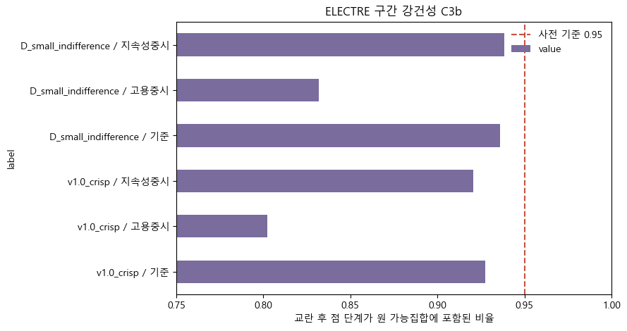

| limitation_id | statement | evidence_g2_b1_value | evidence_employment_revision_p90_pct | evidence_ratio | evidence_n_discriminating | evidence_discriminating_within_p90_rate | evidence_n_combinations_tried | evidence_max_c3_retention_mean | action_taken | what_would_resolve | run_id | run_started_at | input_sha256 | prereg_sha256 | prereg_status | prereg_amendment_ids | phase |
| --- | --- | --- | --- | --- | --- | --- | --- | --- | --- | --- | --- | --- | --- | --- | --- | --- | --- |
| LIM1 | 점 배정은 입력자료 개정 교란에 대해 합격선을 충족하지 못한다. g2의 b1 경계값 2.0%p는 고용 자료 개정폭 90분위 1.944%p와 거의 같은 크기이며(비율 1.029), 판별표본 89행 중 67.4%가 어떤 기준에서든 경계까지의 거리가 개정폭 90분위 안에 있다. Phase 4에서 시도한 18개 조합 전부가 미달했고 최댓값은 0.935였다. 이는 … | 2.000000 | 1.944320 | 1.028637 | 89.000000 | 0.674157 | 18.000000 | 0.935234 | 공식 산출물을 구간 배정으로 전환하고 합격선을 낮추지 않았다. | 자료 개정폭보다 충분히 큰 경계값의 재설계, 또는 개정폭이 작은 자료원의 확보. 현재 자료로는 해결할 수 없다. | 20260916T170959367202Z-ce09d511 | 2026-09-16T17:09:59.367202+00:00 | 58499908a6af50344a1362c55c840a58cfd80d4373c7098c4c97a9e0271a573b | 5c4f3e8664f0eac3c43a9437996398a5a7c7a131db20afc8bf6b751a84eb870c | REGISTERED | AM1,AM2,AM3,AM4,AM5,AM6 | 5.000000 |
| LIM2 | 구간 배정 산출물은 사전등록한 I3(교란 후 점 단계가 가능 단계 집합에 포함되는 비율, 임계 0.95)를 충족하지 못했다(실측 0.893). I3는 자료 불확실성과 파라미터 불확실성을 결합한 지표이며, 가능 단계 집합이 좁을수록 값이 낮아지는 구조를 갖는다(평균 가능 단계 수 1.294). 두 불확실성을 분리해 자료 교란 하의 가능 집합 안정성만 측정한 … | nan | nan | nan | nan | nan | nan | nan | 판정 유지, 지표의 개념 구분을 별도 기록 | 자료 불확실성과 파라미터 불확실성을 분리해 정의한 지표로 사전등록을 다시 하거나, 개정폭이 작은 자료원을 확보하는 것. 현재 자료와 현재 사전등록으로는 해결할 수 없다. | nan | nan | nan | nan | nan | nan | nan |

관찰

- C3b 6개 조합은 모두 사전 기준 0.95에 미달했다. 최고값은 **0.938**이다.

- 독립감사는 기존 표본이 놓친 가능 배정 5건과 I3/Jaccard 평가공간 불일치를 확인했다.

해석

- ELECTRE는 다기준 구조를 표현하는 데 유용하지만 전체 자동판정의 단일 확정값으로 쓰기에는 parameter·자료개정·표집공간 의존성이 컸다.

주의

- 이 결과는 규칙 기반 Triage가 더 정확하다는 검증이 아니다. 정답 label과 현장 정책효과 자료가 없다.

## B. SMAA-TRI — weight uncertainty는 어디까지 해결했는가?

### 문제 → 가설 → 실험

단일 weight 고정의 자의성을 줄이기 위해 명시한 weight·lambda·q/p 공간에서 파라미터를 표집하고 class acceptability와 가능한 단계 집합을 계산했다.

### 결과 → 해석 → 설계 영향

SMAA는 “어떤 가정에서 배정이 얼마나 자주 나오는지”를 보여주지만 정답 weight, 위기확률, 연속공간 전체의 필연성을 주지 않는다. 현재는 추가확인군에서 파라미터 민감 사례를 표시하는 용도로만 사용한다.

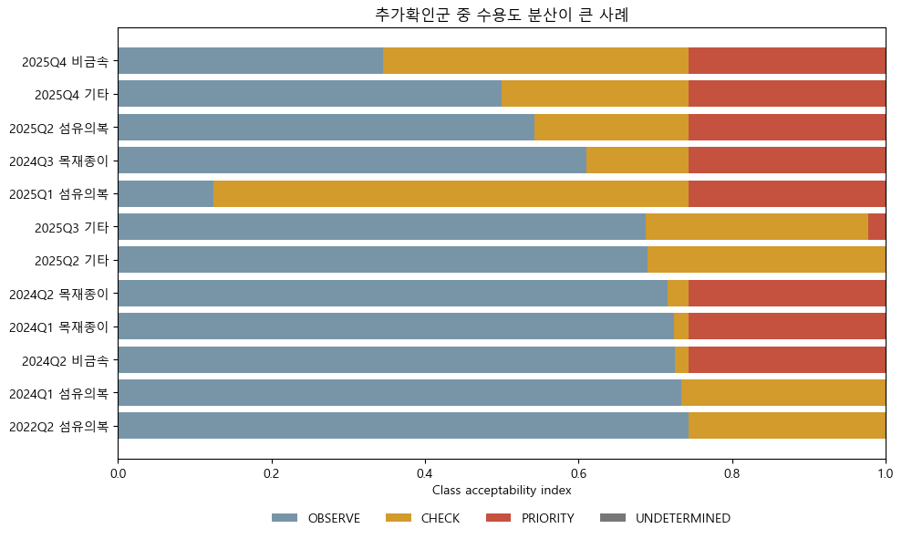

```
가능단계 2개 이상: 29 / 35 | necessary_stage 결측(단일 필연단계 없음): 29
```

## C. Triage robustness / sensitivity

### 문제 → 가설 → 실험

Triage도 운영 threshold에 의존한다. A 경계, 300인 gate, 반복(Q3), 생산(P), R 상위경계, 결측정책을 바꾼 15개 사양을 baseline과 비교했다.

### 결과 → 해석 → 설계 영향

변경 건수와 최신분기 변경을 함께 공개해 “어떤 규칙이 결과에 영향을 주는지”를 숨기지 않는다. baseline 300인은 최적값이 아니라 명시적 운영기준으로 유지한다.

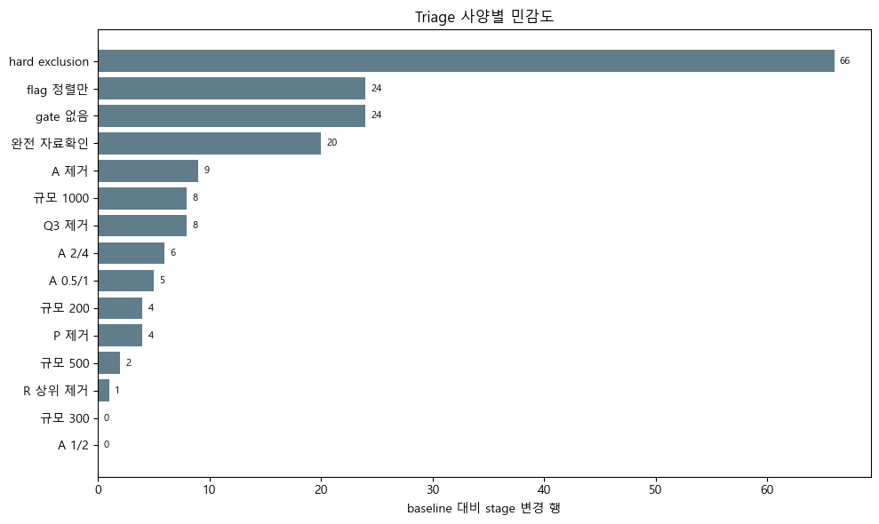

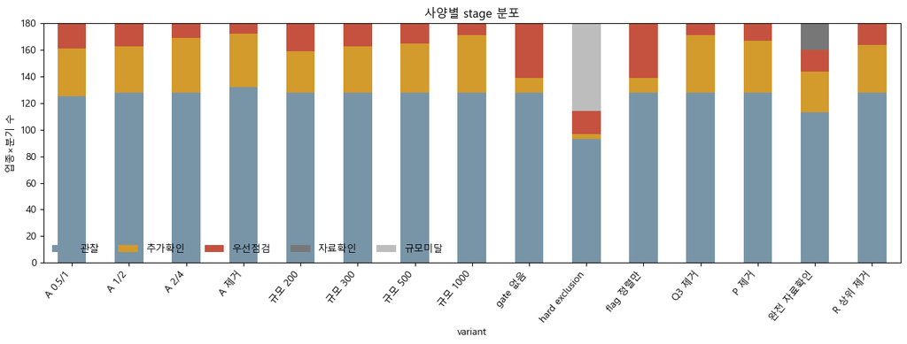

| variant | changed_rows | priority_changed_rows | latest_changed_rows | 우선점검 | 추가확인 | 관찰 | 자료확인 | 규모미달 |
| --- | --- | --- | --- | --- | --- | --- | --- | --- |
| A 0.5/1 | 5 | 2 | 0 | 19 | 36 | 125 | 0 | 0 |
| A 1/2 | 0 | 0 | 0 | 17 | 35 | 128 | 0 | 0 |
| A 2/4 | 6 | 6 | 1 | 11 | 41 | 128 | 0 | 0 |
| A 제거 | 9 | 9 | 1 | 8 | 40 | 132 | 0 | 0 |
| 규모 200 | 4 | 4 | 0 | 21 | 31 | 128 | 0 | 0 |
| 규모 300 | 0 | 0 | 0 | 17 | 35 | 128 | 0 | 0 |
| 규모 500 | 2 | 2 | 1 | 15 | 37 | 128 | 0 | 0 |
| 규모 1000 | 8 | 8 | 1 | 9 | 43 | 128 | 0 | 0 |
| gate 없음 | 24 | 24 | 0 | 41 | 11 | 128 | 0 | 0 |
| hard exclusion | 66 | 0 | 3 | 17 | 4 | 93 | 0 | 66 |
| flag 정렬만 | 24 | 24 | 0 | 41 | 11 | 128 | 0 | 0 |
| Q3 제거 | 8 | 8 | 0 | 9 | 43 | 128 | 0 | 0 |
| P 제거 | 4 | 4 | 1 | 13 | 39 | 128 | 0 | 0 |
| 완전 자료확인 | 20 | 1 | 0 | 16 | 31 | 113 | 20 | 0 |
| R 상위 제거 | 1 | 1 | 0 | 16 | 36 | 128 | 0 | 0 |

```
주요 5개 ablation/강화 사양 모두에서 우선점검 유지: 0/17건
```

| industry | quarter |
| --- | --- |

| industry | quarter | stage | stage_variant | variant |
| --- | --- | --- | --- | --- |
| 기계 | 2022Q1 | 우선점검 | 관찰 | A 제거 |
| 기계 | 2022Q2 | 우선점검 | 관찰 | A 제거 |
| 기계 | 2022Q3 | 우선점검 | 관찰 | A 제거 |
| 기계 | 2022Q4 | 우선점검 | 관찰 | A 제거 |
| 기계 | 2023Q1 | 우선점검 | 추가확인 | A 제거 |
| 기계 | 2023Q2 | 우선점검 | 추가확인 | A 제거 |
| 기계 | 2023Q3 | 우선점검 | 추가확인 | A 제거 |
| 기계 | 2023Q4 | 우선점검 | 추가확인 | A 제거 |
| 기계 | 2026Q2 | 우선점검 | 추가확인 | A 제거 |
| 목재종이 | 2026Q1 | 우선점검 | 추가확인 | 규모 1000 |
| 목재종이 | 2026Q2 | 우선점검 | 추가확인 | 규모 1000 |
| 석유화학 | 2025Q2 | 우선점검 | 추가확인 | 규모 1000 |
| 음식료 | 2025Q1 | 우선점검 | 추가확인 | 규모 1000 |
| 음식료 | 2025Q2 | 우선점검 | 추가확인 | 규모 1000 |
| 음식료 | 2025Q3 | 우선점검 | 추가확인 | 규모 1000 |
| 음식료 | 2025Q4 | 우선점검 | 추가확인 | 규모 1000 |
| 음식료 | 2026Q1 | 우선점검 | 추가확인 | 규모 1000 |
| 기계 | 2022Q1 | 우선점검 | 추가확인 | Q3 제거 |
| 기계 | 2022Q2 | 우선점검 | 추가확인 | Q3 제거 |
| 기계 | 2022Q3 | 우선점검 | 추가확인 | Q3 제거 |
| 기계 | 2023Q1 | 우선점검 | 추가확인 | Q3 제거 |
| 기계 | 2023Q2 | 우선점검 | 추가확인 | Q3 제거 |
| 기계 | 2023Q3 | 우선점검 | 추가확인 | Q3 제거 |
| 기계 | 2023Q4 | 우선점검 | 추가확인 | Q3 제거 |
| 음식료 | 2026Q1 | 우선점검 | 추가확인 | Q3 제거 |

관찰

- gate를 없애면 24건, hard exclusion은 66건, Q3 제거는 8건, P 제거는 4건이 baseline과 달라진다.

- A 제거와 1000인 gate는 최신분기 결과도 각각 1건 바꾼다.

해석

- 규모 gate와 시간·생산 보강이 우선점검 진입을 실제로 제한한다. 따라서 운영기준의 영향은 결과와 함께 공개해야 한다.

주의

- 변경이 적다는 것과 기준이 옳다는 것은 다르다. 안정적 사례도 현장 정답이 확인된 사례는 아니다.

## D. PPI 보정 실험

### 문제 → 가설 → 실험

명목 생산액 변화에는 가격효과가 섞인다. 전국 PPI를 업종에 매핑해 명목 생산 YoY와 가격조정 생산 YoY의 부호와 5% 감소경계를 비교했다.

### 결과 → 해석 → 설계 영향

PPI는 창원산단 물량지수가 아니며 매핑등급이 혼재한다. 그래서 CORE의 상태를 자동 교체하지 않고, 부호가 달라지는 사례를 외부 검증·해석 경고로 남긴다.

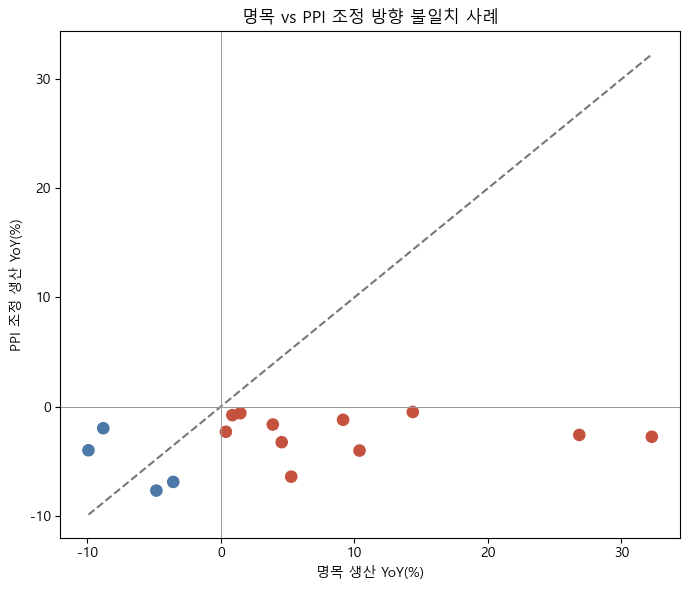

| industry | quarter | nominal_production_yoy | ppi_adjusted_production_yoy | ppi_mapping_grade | sign_agreement | pct5_threshold_agreement |
| --- | --- | --- | --- | --- | --- | --- |
| 목재종이 | 2022Q1 | 10.391674 | -4.021573 | A | False | True |
| 음식료 | 2022Q1 | 3.901018 | -1.638411 | A | False | True |
| 철강 | 2022Q1 | 32.270527 | -2.757162 | B | False | True |
| 비금속 | 2022Q2 | 5.278300 | -6.413934 | A | False | False |
| 음식료 | 2022Q2 | 4.566206 | -3.254183 | A | False | True |
| 철강 | 2022Q2 | 26.842213 | -2.591597 | B | False | True |
| 철강 | 2022Q3 | 9.160979 | -1.203893 | B | False | True |
| 비금속 | 2022Q4 | 14.378100 | -0.488339 | A | False | True |
| 기계 | 2023Q1 | -3.552203 | -6.895718 | A | True | False |
| 기계 | 2023Q2 | 0.388939 | -2.301727 | A | False | True |
| 철강 | 2023Q3 | -9.898771 | -3.993848 | B | True | False |
| 비금속 | 2024Q1 | -4.813588 | -7.686726 | A | True | False |
| 운송장비 | 2024Q1 | 1.469077 | -0.600300 | A | False | True |
| 철강 | 2024Q1 | -8.790854 | -1.978031 | B | True | False |
| 음식료 | 2026Q2 | 0.873432 | -0.779317 | A | False | True |

```
부호 불일치: 11 건 / 기록된 불일치·경계변경 15 건
```

## E. Isolation Forest

저장소의 `src`, notebooks, outputs, logs, Git 이력에서 Isolation Forest 실행 코드·점수·산출물을 확인하지 못했다. 따라서 수행 완료나 보조검증 결과로 기록하지 않는다. 이후 새로 수행한다면 “희귀한 관측형태”를 찾는 독립 보조분석일 뿐 위기 라벨이나 Triage 정답 검증으로 해석해서는 안 된다.

## F. 기타 중요한 과거 실험

| 실험 | 확인된 결과 | 최종 설계 영향 |
| --- | --- | --- |
| 독립 감사 | 표본이 놓친 가능배정 5건, 평가공간 불일치, revision pool 문제 확인 | 단일 확정배정 표현 폐기, HYBRID 결론 |
| 후보모형 비교 | 선호정보 층에 따라 60행 변경, VRC4 의존성 확인 | 규범가정을 운영 출력에서 분리 |
| rolling/hybrid validation | 신규 holdout 정답 검증이 아니라 과거자료 기반 운영범위 점검 | 예측정확도 주장 금지 |
| 외부 context threshold | 가동률·업체수·PPI 보조신호 threshold 변화행 기록 | 외부자료를 판정변수로 승격하지 않음 |

## G. 최종 모형 선택과 선택적 경로 재검증

| 후보 | 목적 | 장점 | 실제 확인된 한계 | 최종 역할 |
| --- | --- | --- | --- | --- |
| Q1~Q3 | 현상진단 | 직관적·역할 분리 | 확인 우선순위 없음 | CORE |
| ELECTRE TRI-B | 다기준 범주분류 | 비보상 구조 | parameter 외적 정당화·개정/표집 안정성 | 추가확인 선택적 재검토 |
| SMAA-TRI | 파라미터 불확실성 | 수용도·가능단계 표시 | 정답 weight·위기확률을 제공하지 않음 | 재검토 robustness |
| Isolation Forest | 이상치 탐지 | 독립적 희귀형태 탐색 가능 | 실행 근거 없음 | 미수행 |
| Rule-based Triage | 1차 선별 | 설명·감사·운영이 쉬움 | 운영 threshold 민감성·정답 label 부재 | 현재 1차 구조 |

```
경로 검증: Triage 추가확인=원천 ELECTRE/SMAA=최종 선택패널=35건; overwrite=0건
```

# 단계 결론

## 확인된 사실

ELECTRE/SMAA는 다기준 구조와 불확실성을 유용하게 보여줬지만, 전체 자동판정을 맡기기에는 외적 정당화·자료개정·파라미터/표집 안정성 한계가 확인됐다. Triage 자체도 gate·A·Q3·P 등에 민감하며 이를 15개 사양으로 공개했다. PPI 보정은 일부 생산 방향과 5% 경계를 바꿨다.

## 해석

현재는 Q1~Q3를 CORE로, 규칙 기반 Triage를 1차 선별로, ELECTRE/SMAA를 추가확인군의 선택적 재검토로 제한하는 HYBRID 구조가 실험 이력과 가장 정합적이다.

## 이 단계만으로 말할 수 없는 것

어느 후보도 현장 정답·인과효과·정책효과를 검증하지 못했다. SMAA는 정답 weight를 찾지 않으며 Triage의 투명성이 정확성 우월성을 뜻하지 않는다.

## 다음 단계가 필요한 이유

모형은 확인 순서를 정하지만 변화 원인을 자동 설명하지 못하므로, 외부자료를 판정을 덮어쓰지 않는 맥락·교차확인 층으로 붙여야 한다.

→ 다음: `04_external_evidence.ipynb`